# Logistic Regression

SOST20131/SOST30031

15 September, 2025

## Logistic Regression

Often in studies, we encounter outcomes that are not continuous, but instead fall into 1 of 2 categories. In these cases we have binary outcomes, variables that can have only two possible values:

- Measuring a performance labelled as $Y$. Candidates are classified as “good” or “poor”, coded as 1 and 0 respectively, i.e. $Y$=1 representing good performance and $Y$=0 representing poor performance.
- Risk factor for cancer: person has cancer ($Y$ = 1), or does not ($Y$ = 0)
- Whether a political candidate is going to win an election: lose $Y$=0, win $Y$=1
- ‘Health’ of a business can be observed by monitoring the solvency of the firm: bankrupt $Y$=0, solvent $Y$=1

Here $Y$ is the binary response variable, that is coded as 0 or 1 and rather than predicting these two values for binary response we try to model the probabilities that $Y$ takes one of these two values.

Let us examine one such example using [the bankruptcies data](https://tanjakec.github.io/mydata/Bankrupticies.csv) available from 👉 https://tanjakec.github.io/mydata/Bankruptcies.csv.

[`Bankruptcies.csv`](https://tanjakec.github.io/mydata/Bankruptcies.csv) file contains data of the operating financial ratios of 66 firms which either went bankrupt or remained solvent after a 2 year period. The data is taken from the book [“Regression Analysis by Example”](https://www.wiley.com/en-us/Regression+Analysis+by+Example%2C+5th+Edition-p-9781118456248) by [Chatterjee](http://people.stern.nyu.edu/schatter/chatterjee.html) and [Hadi](http://www1.aucegypt.edu/faculty/hadi/). The variables are:

- three financial ratios (the explanatory variables; measured variables):
  - $X_1$: Retained Earnings / Total Assets
  - $X_2$: Earnings Before Interest and Taxes / Total Assets
  - $X_3$: Sales / Total Assets
- a binary response variable $Y$:
  - 0 - if bankrupt after 2 years
  - 1 - if solvent after 2 years

```r
> bankrup <- read.csv("https://tanjakec.github.io/mydata/Bankruptcies.csv")
> summary(bankrup)
```

```
##        Y             X1                X2                 X3
##  Min.   :0.0   Min.   :-308.90   Min.   :-280.000   Min.   :0.100
##  1st Qu.:0.0   1st Qu.: -39.05   1st Qu.: -17.675   1st Qu.:1.025
##  Median :0.5   Median :   7.85   Median :   4.100   Median :1.550
##  Mean   :0.5   Mean   : -13.63   Mean   :  -8.226   Mean   :1.721
##  3rd Qu.:1.0   3rd Qu.:  35.75   3rd Qu.:  14.400   3rd Qu.:1.975
##  Max.   :1.0   Max.   :  68.60   Max.   :  34.100   Max.   :6.700
```

Since

1. linear regression expects a numeric response variable and
2. we are interested in the analysis of the risk, ie. the probability of a firm going bankrupt based on its Retained Earnings / Total Assets ratio (RE/TA ratio) figure

it would be very attractive to be able to use the same modelling techniques as for linear models. We are going to do just that: fit a simple linear regression model to examine this relationship to see if it will work.

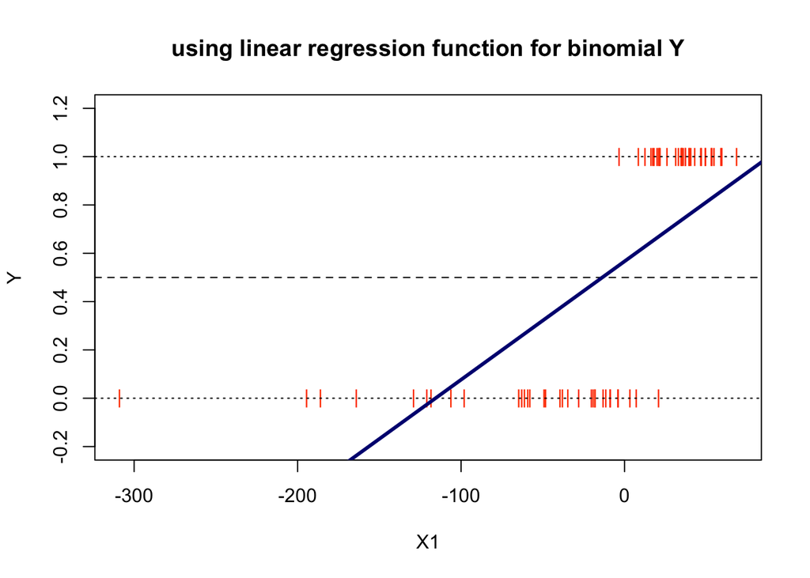

Examining this plot we can make two obvious observations:

1. the higher the ration of RE/TA the better the chances is for the firm to be solvent.
2. by analysing the risk we analyse a chance, a probability of a company being solvent based on the value of the RE/TA. Since $Y$ is limited to the values of 0 and 1, rather than predicting these two values we will try to model the probabilities $p$ that $Y$ takes one of these two values.

Let $p$ denote the probability that $Y$ = 1 when $X = x$. If we use the standard linear model to describe $p$, then our model for the probability would be

$$p = P(Y = 1 | X = x) = b_0 + b_1x +
e$$

Note that since $p$ is a probability it must lie between 0 and 1. It seems rational that $X\hat{b}$ is a reasonable estimate of $P(Y=1∣X=x)$. Nonetheless, the plot has flagged a big issue with this model and that is that it has predicted probabilities less than 0.

As we can see the linear regression model does not work for this type of problem, for which we do not expect predictions that are off-scale values: below zero or above 1.

Apart from the fact that the linear function given is unbounded, and hence cannot be used to model probability, the other assumptions of linear regression when dealing with this type of a problem are also not valid:

- the relationship between $Y$ and $X$ is nonlinear
- error terms are not normally distributed
- the assumption of equal/constant variance (homoscedasticity) dos not hold

A workaround these issues is to fit a different model, one that is bounded by the minimum and maximum probabilities. It makes better sense to model the probabilities on a transformed scale and this is what is done in logistic regression analysis. The relationship between the probability $p$ and $X$ can be presented by a **logistic regression function**.

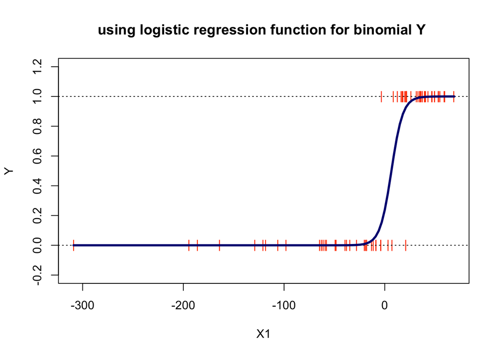

The shape of the S-curve given in the figure above can be reproduced if we model the probabilities as follows

$$p = P(Y = 1 | X = x) = \frac{e^{\beta_0
+ \beta_1x}}{1 + e^{\beta_0 + \beta_1x}},$$

where $e$ is the base of the natural logarithm. The logistic model can be generalized directly to the situation where we have several predictor variables. The probability $p$ is modelled as

$$p = P(Y = 1 | X_1 = x_1, X_2=x_2, ...,
X_q=x_q) = \frac{e^{\beta_0 + \beta_1x_1 + \beta_2x_2 + ... +
\beta_qx_q}}{1 + e^{\beta_0 + \beta_1x_1 + \beta_2x_2 + ... +
\beta_qx_q}},$$
where $q$ is the number of predictors. The two equations above are called the logistic regression functions. It is nonlinear in the parameters $\beta_0, \beta_1,... \beta_q$. However, it can be linearised by the **logit transformation**. Instead of working directly with $p$ we work with a transformed value of $p$. If $p$ is the probability of an event happening, the ratio $\frac{p}{(1-p)}$ is called the **odds ratio** for the event. By moving some terms around

$$1 - p = P(Y = 1 | X_1 = x_1, X_2=x_2,
..., X_q=x_q) = \frac{1}{1 + e^{\beta_0 + \beta_1x_1 + \beta_2x_2 + ...
+ \beta_qx_q}},$$
we get

$$\frac{p}{1-p} = e^{\beta_0 + \beta_1x_1
+ \beta_2x_2 + ... + \beta_qx_q}$$
Taking the natural logarithm of both sides of the above expression, we obtain

$$g(x_1, x_2, ... x_q) =
log(\frac{p}{1-p}) = \beta_0 + \beta_1x_1 + \beta_2x_2 + ... +
\beta_qx_q$$
where the logarithm of the odds ratio is called the **logit**. We realise that the logit transformation produces a linear function of the parameters $\beta_0, \beta_1,... \beta_q$. It is important to realise is that while the range of values of $p$ of binomial response $Y$ is between 0 and 1, the range of values of $log\frac{p}{(1-p)}$ is between $-\infty$ and $+\infty$. This makes the logarithm of the odds ratio, known as logits, more appropriate for linear regression fitting.

In logistic regression the response probabilities are modelled by the logistic distribution function. That is, the model does not use the binned version of the predictor, but rather the log odds are modelled as a function of the predictor. The model parameters are estimated by working with logits which produces a model that is linear in the parameters.

The method of model estimation is the **maximum likelihood** method. Maximum likelihood parameter estimation is a technique that can be used when we can make assumptions about the probability distribution of the data. Based on the theoretical probability distribution and the observed data, the likelihood function is a probability statement that can be made about a particular set of parameter values. In logistic regression modelling the maximum likelihood parameters are obtained numerically using an interactive procedure. This is explained in the [book by McCullagh and Nelder](http://www.utstat.toronto.edu/~brunner/oldclass/2201s11/readings/glmbook.pdf) in Section 4.4.2.

Although the method of maximum likelihood is used for the model estimation we ask the same set of questions that are usually considered in linear regression. That is, we can not use the very familiar least square regression tools such as $R^2$, $t$ and $F$, but that is not to say that we are not able to answer the same questions as we do when assessing a linear regression model for which we use the listed tools.

[John Nelder](https://en.wikipedia.org/wiki/John_Nelder) and Robert Wedderburn formulated a modelling technique for accommodating response variables with non-normal conditional distribution. Logistic regression and ordinary linear regression fall into this larger class of techniques called [**Generalised Linear Models**](https://docs.ufpr.br/~taconeli/CE225/Artigo.pdf) (**GLM**s) which accommodate many different probability distributions. They substantially extend the range of application of linear statistical models by accommodating response variables with non-normal conditional distribution. Except for the error, the right hand side of a GLM model equation is basically the same as for a linear model. This is reflected in the syntax of the `glm()` function in R, which expects the formula that specifies the right-hand side of GLM to be the same as those used for the least square linear regression model, with the addition of description for the error distribution.

## Using the `glm()` function

Through this example we will fit a logistic regression model using the `glom` function in order to learn how such models are fitted and evaluated.

We have already uploaded the [`Bankrupticies.csv`](https://tanjakec.github.io/mydata/Bankruptcies.csv) data file, which contains information of the operating financial ratios of 66 firms which either went bankrupt or remained solvent after a 2 year period earlier. Hence, the response variable is defined as

$Y$:

- 0 - if bankrupt after 2 years
- 1 - if solvent after 2 years

Here, we will instead of predicting $Y$, fit the model to predict the logits $log\frac{p}{(1-p)}$, which after transformation means we can get the predicted probabilities for $Y$.

Let us remind ourselves what the data looks like.

```r
> suppressPackageStartupMessages(library(dplyr))
>
> bankrup <- read.csv("https://tanjakec.github.io/mydata/Bankruptcies.csv")
> summary(bankrup)
```

```
##        Y             X1                X2                 X3
##  Min.   :0.0   Min.   :-308.90   Min.   :-280.000   Min.   :0.100
##  1st Qu.:0.0   1st Qu.: -39.05   1st Qu.: -17.675   1st Qu.:1.025
##  Median :0.5   Median :   7.85   Median :   4.100   Median :1.550
##  Mean   :0.5   Mean   : -13.63   Mean   :  -8.226   Mean   :1.721
##  3rd Qu.:1.0   3rd Qu.:  35.75   3rd Qu.:  14.400   3rd Qu.:1.975
##  Max.   :1.0   Max.   :  68.60   Max.   :  34.100   Max.   :6.700
```

```r
> glimpse(bankrup)
```

```
## Rows: 66
## Columns: 4
## $ Y  <int> 0, 0, 0, 0, 0, 0, 0, 0, 0, 0, 0, 0, 0, 0, 0, 0, 0, 0, 0, 0, 0, 0, 0…
## $ X1 <dbl> -62.8, 3.3, -120.8, -18.1, -3.8, -61.2, -20.3, -194.5, 20.8, -106.1…
## $ X2 <dbl> -89.5, -3.5, -103.2, -28.8, -50.6, -56.2, -17.4, -25.8, -4.3, -22.9…
## $ X3 <dbl> 1.7, 1.1, 2.5, 1.1, 0.9, 1.7, 1.0, 0.5, 1.0, 1.5, 1.2, 1.3, 0.8, 2.…
```

Before we start the model fitting procedure we will make test-train split data in the proportion of 80:20.

```r
> set.seed(123)
> split_idx = sample(nrow(bankrup), 53)
> bankrup_train = bankrup[split_idx, ]
> bankrup_test = bankrup[-split_idx, ]
```

We will have a quick glance at data to see what the training data is like

```r
> glimpse(bankrup_train)
```

```
## Rows: 53
## Columns: 4
## $ Y  <int> 0, 1, 0, 0, 1, 1, 1, 1, 1, 1, 1, 1, 0, 0, 0, 0, 1, 0, 0, 0, 1, 0, 1…
## $ X1 <dbl> -8.8, 31.4, 7.2, -120.8, 68.6, 18.1, 40.6, 37.3, 35.0, 21.5, 59.5, …
## $ X2 <dbl> -9.1, 15.7, -22.6, -103.2, 13.8, 13.5, 5.8, 33.4, 20.8, -14.4, 7.0,…
## $ X3 <dbl> 0.9, 1.9, 2.0, 2.5, 1.6, 4.0, 1.8, 3.5, 1.9, 1.0, 2.0, 2.0, 2.1, 2.…
```

```r
> summary(as.factor(bankrup_train$Y))
```

```
##  0  1
## 28 25
```

```r
> summary(bankrup_train)
```

```
##        Y                X1                X2                X3
##  Min.   :0.0000   Min.   :-308.90   Min.   :-280.00   Min.   :0.10
##  1st Qu.:0.0000   1st Qu.: -39.40   1st Qu.: -20.80   1st Qu.:1.10
##  Median :0.0000   Median :   3.30   Median :   1.60   Median :1.60
##  Mean   :0.4717   Mean   : -17.83   Mean   : -11.93   Mean   :1.76
##  3rd Qu.:1.0000   3rd Qu.:  35.00   3rd Qu.:  13.50   3rd Qu.:2.00
##  Max.   :1.0000   Max.   :  68.60   Max.   :  33.40   Max.   :6.70
```

We have a nice split in terms of the number of observations for each class of Y. Next, we estimate a logistic regression model using the `glm()` (generalised linear model) function which we save as an object.

```r
> model <- glm(Y ~ X1 + X2 + X3, data = bankrup_train, family = binomial(logit))
> model
```

```
##
## Call:  glm(formula = Y ~ X1 + X2 + X3, family = binomial(logit), data = bankrup_train)
##
## Coefficients:
## (Intercept)           X1           X2           X3
##     -9.8846       0.3238       0.1779       4.9443
##
## Degrees of Freedom: 52 Total (i.e. Null);  49 Residual
## Null Deviance:       73.3
## Residual Deviance: 5.787     AIC: 13.79
```

In order to get all the results saved in the `glm_model` object we use the summary command.

```r
> summary(model)
```

```
##
## Call:
## glm(formula = Y ~ X1 + X2 + X3, family = binomial(logit), data = bankrup_train)
##
## Coefficients:
##             Estimate Std. Error z value Pr(>|z|)
## (Intercept)  -9.8846    10.6564  -0.928    0.354
## X1            0.3238     0.2959   1.094    0.274
## X2            0.1779     0.1079   1.650    0.099 .
## X3            4.9443     5.0231   0.984    0.325
## ---
## Signif. codes:  0 '***' 0.001 '**' 0.01 '*' 0.05 '.' 0.1 ' ' 1
##
## (Dispersion parameter for binomial family taken to be 1)
##
##     Null deviance: 73.3037  on 52  degrees of freedom
## Residual deviance:  5.7875  on 49  degrees of freedom
## AIC: 13.787
##
## Number of Fisher Scoring iterations: 12
```

The key components of R’s summary( ) function for generalised linear models for binomial family with the logit link are:

- **Call**: just like in the case of fitting the `lm()` model this is R reminding us what model we ran, what options we specified, etc

- the **Coefficients**, their standard errors, the z-statistic (sometimes called a Wald z-statistic), and the associated p-values. The logistic regression coefficients give the change in the log odds of the outcome for a one unit increase in the predictor variable

At the end there are **fit indices**, including the null and deviance residuals and the AIC, which are used to assess overall model fit.

We realise that the output above has a resemblance to the standard regression output. Although they differ in the type of information, they serve similar functions. Let us make an interpretation of it.

The fitted logarithm of the odds ratio, i.e. logit of the probability $p$ of the firm remaining solvent after two years is modelled as:

$$\hat{g}(X_1, X_2, ...X_q) = -9.8846
+ 0.3238X_1 + 0.1779X_2 + 4.9443X_3$$
Remember that here instead of predicting $Y$ we obtain the model to predict $\log\frac{p}{(1-p)}$. Using the transformation of the logit we get the predicted probabilities of the firm being solvent.

The estimated parameters are expected changes in the logit for unit change in their corresponding variables when the other, remaining variables are held fixed. That is, the logistic regression coefficients give the change in the log odds of the response variable for a unit increase in the explanatory variable:

This is very hard to make sense of. We have predicted log odds and in order to interpret them into a more sensible fashion we need to “anti logge” them as the changes in odds ratio for a unit change in variable $X_i$, while the other variables are held fixed $e^(\beta_i)$.

```r
> round(exp(coef(model)), 4)
```

```
## (Intercept)          X1          X2          X3
##      0.0001      1.3823      1.1947    140.3731
```

Now, we can interpret the coefficients of the ratios as follows:

- The odds of a firm being solvent (vs being bankrupt) increases by 1.38 for a unit change in ratio $X_1$, all else in the model being being fixed. That is, for an increase in $X_1$ the relative odds of
  $$\frac{P(Y=1)}{P(Y=0)}$$

is multiplied by $e^{\beta_1} = e^{0.3238} = 1.38$, implying that there is an increase of $38\%$